The Walk to Mordor / The Walking Data EDA ← About

# The Walk to Mordor

## The Walking Data Exploratory Data Analysis

An investigation of personal walking data spanning three virtual Middle-earth challenges completed through [The Conqueror](https://www.theconqueror.events/):

| Journey | Character | Period | Target miles |
| --- | --- | --- | --- |
| Mordor | Frodo | Mar 2024 – Jan 2025 | 1,815 |
| Return of the King | Aragorn | Jan 2025 – Aug 2025 | 1,482 |
| The Hobbit | Bilbo | Jan 2026 – Jun 2026 | 1,100 |

**Data source:** Google Fit export processed in `etl.ipynb`.  
Only `data/processed/` is read here — no raw health data is loaded.

## 1. Setup

```
Daily rows : 806   (2024-03-27 → 2026-06-10)
Segments   : 11
Challenge-assigned days : 628
```

## 2. At a Glance

Before examining the detail, here is a one-table summary of the three challenges.

| Character | Frodo | Aragorn | Bilbo |
| --- | --- | --- | --- |
| Period | Mar 2024 – Jan 2025 | Jan 2025 – Aug 2025 | Jan 2026 – Jun 2026 |
| Calendar days | 287 | 225 | 142 |
| Active days | 261 | 225 | 142 |
| Total miles | 1823.0 | 1493.5 | 1148.1 |
| Target miles | 1815 | 1482 | 1100 |
| vs target | 100.4% | 100.8% | 104.4% |
| Avg mi/day | 6.98 | 6.64 | 8.09 |
| Median mi/day | 7.12 | 6.49 | 7.93 |
| Peak day (mi) | 17.37 | 16.72 | 16.43 |

All three journeys **exceeded** their Conqueror target distances.

Bilbo's 142-day journey stands apart: the highest average (8.09 mi/day) and the highest median (7.93 mi/day) of the three, despite covering the least total mileage. In roughly half the calendar time of Frodo's challenge, Bilbo covered more than 60% of the same distance — a sustained, compressed effort.

Across all three challenges: roughly **4,465 miles** of walking assigned to a challenge segment, and **5,196 miles** total across the full project window including gap periods.

## 3. Daily Activity Over Time

The complete daily record coloured by challenge period.  
A 14-day centred rolling average reveals the underlying pace.

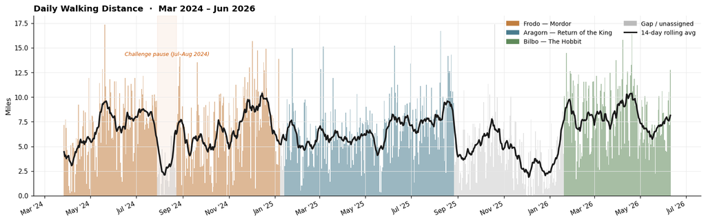

## 4. Calendar View

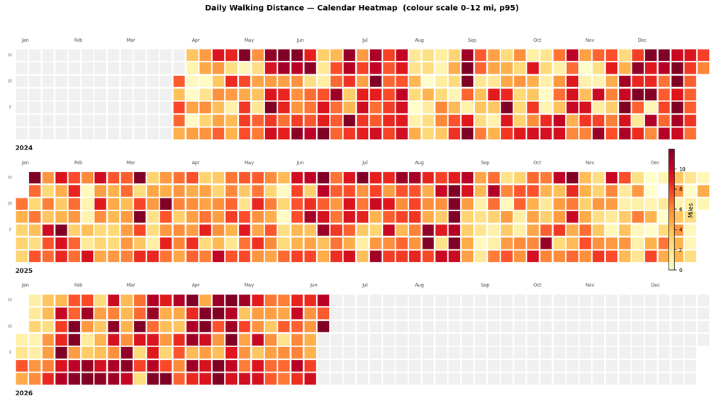

**Near-continuous activity.** There are almost no completely light (≤ 1 mile) cells across three years — the walking habit was genuinely daily rather than episodic.

**The Aragorn–Bilbo gap (Sep 2025 – Jan 2026)** is the most visible quiet period. Even so, the cells are not white — they show moderate activity throughout, confirming that the inter-journey period was not a rest period.

## 5. Accumulated Distance

Total walking miles accumulated day by day.  
Dot colour shows which challenge was active; grey indicates gap or unassigned days. The slope reflects pace.

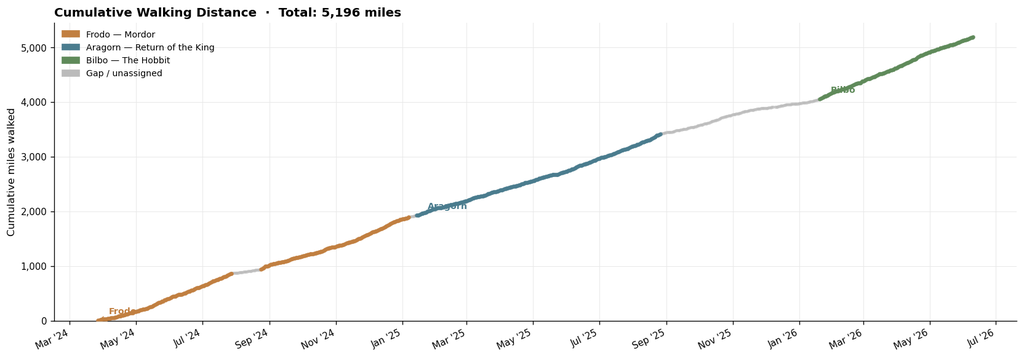

The cumulative chart reaches roughly **5,200 miles** by the end of the Bilbo challenge — a figure that includes 730+ miles walked during gap periods between challenges.

Two slope signatures stand out:

- **The Bilbo section** (far right, green) has the steepest gradient, consistent with the highest daily average of the three challenges.
- **The Aragorn–Bilbo gap** (long grey stretch, Aug 2025 – Jan 2026) continues accumulating at a steady ~4 miles/day across 147 days — slower than the challenge pace, but never stopping.

The absence of any truly flat section confirms what the calendar showed: this was a walking habit, not a challenge-driven burst.

## 6. How Do the Three Journeys Compare?

Key metrics side by side.

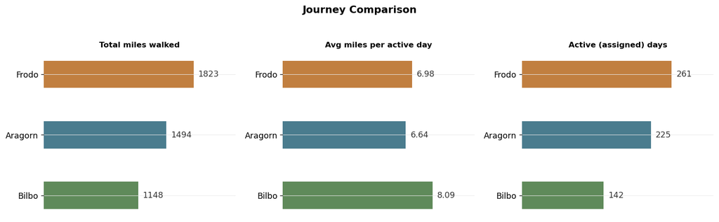

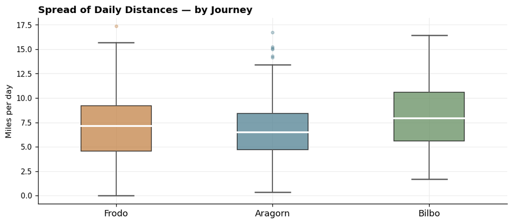

**Frodo** shows the widest spread: the most days below 2 miles (9.2% of assigned days) but also the highest single-day peak (17.37 mi). His journey's length — 261 days across multiple seasons — naturally accommodated more variability.

**Bilbo** sits highest overall: median 7.93, mean 8.09, and only 1 day in 142 fell below 2 miles. The Hobbit challenge was clearly approached with intensity from the outset.

## 7. Distribution of Daily Distances

What does a typical challenge day look like across the three journeys?

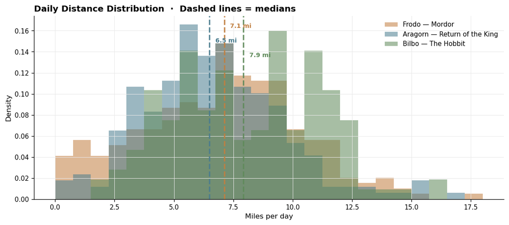

All three journeys share the same general shape: roughly unimodal, centred between 6 and 9 miles, with a right-hand tail extending to 15+ miles and a smaller left-side cluster of lower-distance days.

This distribution does not look like someone walking a fixed daily target. It looks like a person with an active daily life whose walking naturally varies — accumulating distance in stretches of 8–12 mile days punctuated by lighter days, rather than hitting a steady 7.0 miles every morning.

The left cluster (below 3 miles) deserves a note: Google Fit records any detectable movement, so these low-distance days likely represent days when the phone was carried but little deliberate walking occurred — the data does not contain a single true zero-step day.

## 8. Temporal Patterns

Does walking behaviour vary by day of the week or by month?

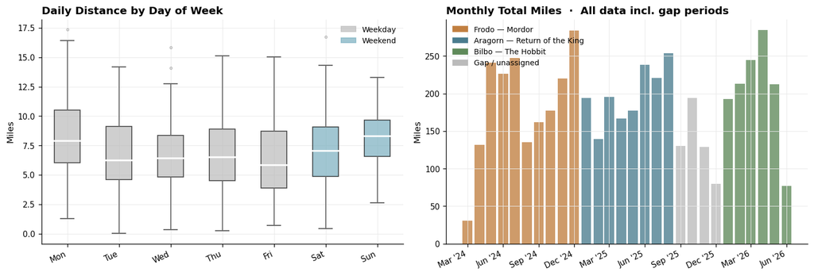

**Day of week:** Sunday and Monday produce the highest medians (8.33 and 7.93 miles respectively); Friday the lowest (5.85 miles). The weekend uptick is modest but consistent — likely reflecting longer walks when unstructured time is available. The Friday dip may reflect end-of-week fatigue or early finishes cutting into afternoon walking time.

What's notable is the *absence* of a dramatic pattern: the medians range only from ~5.9 to 8.3 miles across all seven days. This is not a weekend-warrior profile — it is a daily walker with slight weekend preference.

**Monthly totals:** Monthly accumulated mileage is broadly even across all three challenge periods, with no seasonal collapse. The long grey bar in the Sep 2025 – Jan 2026 window reflects the Aragorn–Bilbo inter-journey gap: lower monthly totals than challenge months, but persistent.

## 9. Walking Streaks

An unbroken streak of meaningful walking days, using a 2-mile threshold to filter incidental phone-pocket movement.

```
Total days with ≥ 2.0 mi : 728  of  806 in project range
Total break days             : 78

Top 8 streaks:
     start        end  days  total  avg
2026-02-06 2026-06-10   125  994.0 7.95
2025-03-16 2025-05-19    65  392.5 6.04
2025-07-06 2025-09-02    59  457.9 7.76
2024-12-07 2025-02-03    59  443.3 7.51
2024-06-13 2024-07-28    46  385.0 8.37
2025-05-23 2025-07-04    43  316.2 7.35
2025-10-09 2025-11-12    35  217.8 6.22
2025-02-09 2025-03-14    34  200.2 5.89
```

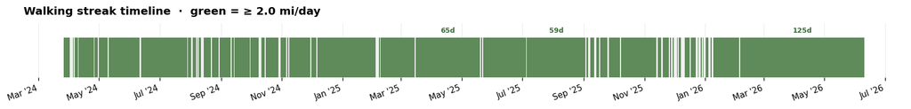

## Key Findings

[output not shown]

*These findings provide the analytical foundation for the narrative layer of the GitHub Pages visualisation.*